# Curso de Métodos Intensivos de Computación Estadística

## Practica 1

En esta práctica, vamos a escribir una función (script) para hacer la gráfica de la función:

$$ y=\sin x $$

A continuación mostramos una imagen que muestra cómo se ve esta función:

[figure not shown]

Así como un video con sus propiedades:

```python
from IPython.display import YouTubeVideo

video_seno = YouTubeVideo('JwGW8YyNp4M')

display(video_seno)
```

[video not shown]

Ahora, para la construcción de la función (script) que grafique la función seno, procedemos comos siguie:

**1.** Importamos las librerias que vamos a utilizar

```python
import numpy as np
import matplotlib.pyplot as plt
```

**2.** Constuimos una función $f(x)$ que nos devuelva el valos de $\sin x$ para un $x \in \mathbb R$ dado.

```python
def f(x):
    return(np.sin(x))
```

**3.** Definimos el intervalo en el cual queremos graficar la función

```python
limite_inferior=-2*np.pi
limite_superior=2*np.pi
```

**4.** Así, generamos el gráfico de la función que acabamos de definir en los límites establecidos.

```python
x = np.arange(limite_inferior,limite_superior,0.01)
y = f(x)
```

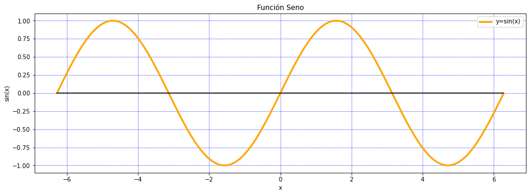

```python
plt.figure(figsize=(15, 5))
plt.plot(x,y,color="orange",label='y=sin(x)',linewidth=3)
plt.plot(x,y*0,color="black")
plt.xlabel('x')
plt.ylabel('sin(x)')
plt.title('Función Seno')
plt.grid(color='b', linestyle='--', linewidth=.5)
plt.legend()
plt.show()
```

Análogamente, procederemos a construir la gráfica de la función $\cos x$:

```python
def g(x):
    return(np.cos(x))
```

```python
x = np.arange(limite_inferior,limite_superior,0.01)
z = g(x)
```

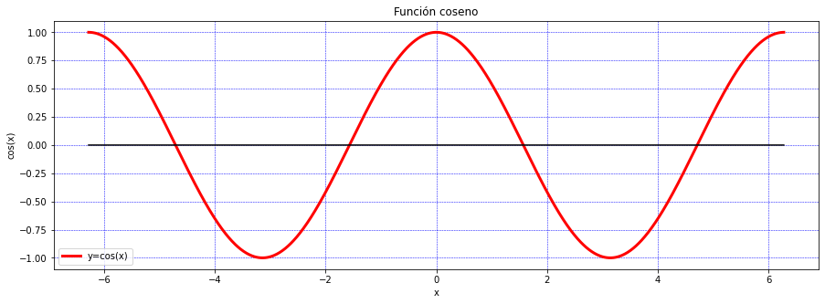

```python
plt.figure(figsize=(15, 5))
plt.plot(x,z,color="Red",label='y=cos(x)',linewidth=3)
plt.plot(x,y*0,color="black")
plt.xlabel('x')
plt.ylabel('cos(x)')
plt.title('Función coseno')
plt.grid(color='b', linestyle='--', linewidth=.5)
plt.legend()
plt.show()
```

Así mismo, a continuación se puede encontrar documentación sobre la función [coseno](https://es.wikipedia.org/wiki/Coseno), así como un video sobre sus propiedades:

```python
from IPython.display import YouTubeVideo

video_coseno = YouTubeVideo('7Zef_6kdOzs')

display(video_coseno)
```

[video not shown]

Finalmente, procedemos con una gráfica conjunta de ambas funciones (Seno y Coseno):

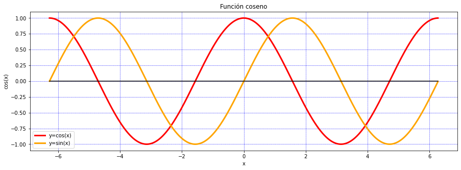

```python
plt.figure(figsize=(15, 5))
plt.plot(x,z,color="Red",label='y=cos(x)',linewidth=3)
plt.plot(x,y,color="orange",label='y=sin(x)',linewidth=3)
plt.plot(x,y*0,color="black")
plt.xlabel('x')
plt.ylabel('cos(x)')
plt.title('Función coseno')
plt.grid(color='b', linestyle='--', linewidth=.5)
plt.legend()
plt.show()
```

Por supuesto, acompañamos esta gráfica con su respectiva [documentación](https://en.wikipedia.org/wiki/Sine_and_cosine), así como un video con relaciones interesantes acerca de estas dos funciones:

```python
seno_y_coseno = YouTubeVideo('XH3htlWU9N4')

display(seno_y_coseno)
```

[video not shown]

[figure not shown]